# Assignment10

Frank Bonifazi

6/17/2019

## Before Starting:

Read about the data at https://github.com/rfordatascience/tidytuesday/tree/master/data/2019/2019-05-21

```r
coast_vs_waste <- readr::read_csv("https://raw.githubusercontent.com/rfordatascience/tidytuesday/master/data/2019/2019-05-21/coastal-population-vs-mismanaged-plastic.csv")
mismanaged_vs_gdp <- readr::read_csv("https://raw.githubusercontent.com/rfordatascience/tidytuesday/master/data/2019/2019-05-21/per-capita-mismanaged-plastic-waste-vs-gdp-per-capita.csv")
waste_vs_gdp <- readr::read_csv("https://raw.githubusercontent.com/rfordatascience/tidytuesday/master/data/2019/2019-05-21/per-capita-plastic-waste-vs-gdp-per-capita.csv")
```

# Begin EDA

```r
# Clean Names - helps quite a bit!
coast_vs_waste = coast_vs_waste %>% janitor::clean_names()
#FB: All lower-case with "_" underscores between words!

mismanaged_vs_gdp = mismanaged_vs_gdp %>% janitor::clean_names()

waste_vs_gdp = waste_vs_gdp %>% janitor::clean_names()
```

```r
coast_vs_waste %>%
  colnames()
```

```
## [1] "entity"                          "code"
## [3] "year"                            "mismanaged_plastic_waste_tonnes"
## [5] "coastal_population"              "total_population_gapminder"
```

# Explore NA values

Show how many `NA` there are and how to interpret these `NA` values

```r
coast_vs_waste %>%
  filter(is.na(entity)) #%>%
```

```
## # A tibble: 0 x 6
## # … with 6 variables: entity <chr>, code <chr>, year <dbl>,
## #   mismanaged_plastic_waste_tonnes <dbl>, coastal_population <dbl>,
## #   total_population_gapminder <dbl>
```

```r
  #count()  FB: Why does count say 1???
# Zero NAs
```

```r
coast_vs_waste %>%
  filter(is.na(code))
```

```
## # A tibble: 0 x 6
## # … with 6 variables: entity <chr>, code <chr>, year <dbl>,
## #   mismanaged_plastic_waste_tonnes <dbl>, coastal_population <dbl>,
## #   total_population_gapminder <dbl>
```

```r
  #FB: zero NAs
```

```r
coast_vs_waste %>%
  filter(is.na(year))
```

```
## # A tibble: 0 x 6
## # … with 6 variables: entity <chr>, code <chr>, year <dbl>,
## #   mismanaged_plastic_waste_tonnes <dbl>, coastal_population <dbl>,
## #   total_population_gapminder <dbl>
```

```r
  #FB: zero NAs
```

```r
coast_vs_waste %>%
  filter(is.na(mismanaged_plastic_waste_tonnes)) %>%
 count()
```

```
## # A tibble: 1 x 1
##       n
##   <int>
## 1 19906
```

```r
#print(n)
#coast_vs_waste_NAs <- n
#print(n)
  #FB: 19,906 NAs
```

```r
coast_vs_waste %>%
  filter(is.na(coastal_population))
```

```
## # A tibble: 19,907 x 6
##    entity  code   year mismanaged_plasti… coastal_populat… total_populatio…
##    <chr>   <chr> <dbl>              <dbl>            <dbl>            <dbl>
##  1 Afghan… AFG    1800                 NA               NA          3280000
##  2 Afghan… AFG    1820                 NA               NA          3280000
##  3 Afghan… AFG    1870                 NA               NA          4207000
##  4 Afghan… AFG    1913                 NA               NA          5730000
##  5 Afghan… AFG    1950                 NA               NA          8151455
##  6 Afghan… AFG    1951                 NA               NA          8276820
##  7 Afghan… AFG    1952                 NA               NA          8407148
##  8 Afghan… AFG    1953                 NA               NA          8542906
##  9 Afghan… AFG    1954                 NA               NA          8684494
## 10 Afghan… AFG    1955                 NA               NA          8832253
## # … with 19,897 more rows
```

```r
  #FB: 19,907 NAs
```

```r
coast_vs_waste %>%
  filter(is.na(total_population_gapminder))
```

```
## # A tibble: 12 x 6
##    entity   code    year mismanaged_plas… coastal_populat… total_populatio…
##    <chr>    <chr>  <dbl>            <dbl>            <dbl>            <dbl>
##  1 Channel… OWID_…  2010              281           153352               NA
##  2 Curacao  CUW     2010              268           143784               NA
##  3 Falklan… FLK     2010                5             2602               NA
##  4 Guernsey GGY     2010              103            56289               NA
##  5 Microne… FSM     2010             4794           154895               NA
##  6 Netherl… ANT     2010              416           227165               NA
##  7 Norfolk… NFK     2010               68             2156               NA
##  8 Palesti… PSE     2010             5599          3045258               NA
##  9 Saint P… SPM     2010               11             5888               NA
## 10 Sint Ma… SXM     2010               70            37429               NA
## 11 World    OWID_…  2010         31865274               NA               NA
## 12 Yemen    YEM     2010           169181          6048920               NA
```

```r
  #FB: 12 NAs
```

< 39,825 > FB: Per data_frame? Total # NAs in coast_vs.waste = 39,825

Are there any groups of data with `NA` that stand out? Why or why not?

```r
coast_vs_waste %>%
  select(mismanaged_plastic_waste_tonnes, total_population_gapminder) %>%
filter(is.na (mismanaged_plastic_waste_tonnes)) %>%
 filter(is.na (total_population_gapminder))
```

```
## # A tibble: 0 x 2
## # … with 2 variables: mismanaged_plastic_waste_tonnes <dbl>,
## #   total_population_gapminder <dbl>
```

FB: - Columns: mismanaged_plastic_waste_tonnes and total_population_gapminder don’t have NAs in the same rows.

```r
mismanaged_vs_gdp %>%
  colnames()
```

```
## [1] "entity"
## [2] "code"
## [3] "year"
## [4] "per_capita_mismanaged_plastic_waste_kilograms_per_person_per_day"
## [5] "gdp_per_capita_ppp_constant_2011_international_rate"
## [6] "total_population_gapminder"
```

```r
mismanaged_vs_gdp %>%
  filter(is.na(entity)) %>%
  count()
```

```
## # A tibble: 1 x 1
##       n
##   <int>
## 1     0
```

FB: Zero NAs

```r
mismanaged_vs_gdp %>%
  filter(is.na(code)) %>%
count()
```

```
## # A tibble: 1 x 1
##       n
##   <int>
## 1  1240
```

FB: 1,240 NAs. NOTE: Maybe there are codes for these countries in the other tables!

```r
mismanaged_vs_gdp %>%
  filter(is.na(year)) %>%
count()
```

```
## # A tibble: 1 x 1
##       n
##   <int>
## 1     0
```

FB: Zero NAs

```r
mismanaged_vs_gdp %>%
  filter(is.na(per_capita_mismanaged_plastic_waste_kilograms_per_person_per_day)) %>%
  count()
```

```
## # A tibble: 1 x 1
##       n
##   <int>
## 1 22018
```

$FB: Wow 22,018 NAs…. could this be calculated from other vars???

```r
mismanaged_vs_gdp %>%
  filter(is.na(gdp_per_capita_ppp_constant_2011_international_rate)) %>%
  count()
```

```
## # A tibble: 1 x 1
##       n
##   <int>
## 1 15797
```

#FB: 15,797 NAs.

```r
mismanaged_vs_gdp %>%
  filter(is.na(total_population_gapminder)) %>%
  count()
```

```
## # A tibble: 1 x 1
##       n
##   <int>
## 1  2123
```

Show how many `NA` there are and how to interpret these `NA` values

```r
waste_vs_gdp %>%
  colnames()
```

```
## [1] "entity"
## [2] "code"
## [3] "year"
## [4] "per_capita_plastic_waste_kilograms_per_person_per_day"
## [5] "gdp_per_capita_ppp_constant_2011_international_constant_2011_international"
## [6] "total_population_gapminder"
```

```r
waste_vs_gdp %>%
  filter(is.na(entity)) %>%
  count()
```

```
## # A tibble: 1 x 1
##       n
##   <int>
## 1     0
```

#FB: Zerop NAs

```r
waste_vs_gdp %>%
  filter(is.na(code)) %>%
  count()
```

```
## # A tibble: 1 x 1
##       n
##   <int>
## 1  1240
```

#FB: There are 1,240 NAs in code….same number (could be different ones though) as in mismanaged_vs_gdp. Need to compare.

```r
waste_vs_gdp %>%
  filter(is.na(year)) %>%
  count()
```

```
## # A tibble: 1 x 1
##       n
##   <int>
## 1     0
```

#FB: Zero NAs

```r
waste_vs_gdp %>%
  filter(is.na(per_capita_plastic_waste_kilograms_per_person_per_day)) %>%
  count()
```

```
## # A tibble: 1 x 1
##       n
##   <int>
## 1 22018
```

#FB: 22,018 NAs.

```r
waste_vs_gdp %>%
  filter(is.na(gdp_per_capita_ppp_constant_2011_international_constant_2011_international)) %>%   count()
```

```
## # A tibble: 1 x 1
##       n
##   <int>
## 1 15797
```

#FB: 15,797 NAs.

```r
waste_vs_gdp %>%
  filter(is.na(total_population_gapminder)) %>%
  count()
```

```
## # A tibble: 1 x 1
##       n
##   <int>
## 1  2123
```

#FB: 2,123 NAs

```r
waste_vs_gdp  #FB: What do you want me to do here????
```

```
## # A tibble: 22,204 x 6
##    entity  code   year per_capita_plast… gdp_per_capita_p… total_populatio…
##    <chr>   <chr> <dbl>             <dbl>             <dbl>            <dbl>
##  1 Afghan… AFG    1800                NA                NA          3280000
##  2 Afghan… AFG    1820                NA                NA          3280000
##  3 Afghan… AFG    1870                NA                NA          4207000
##  4 Afghan… AFG    1913                NA                NA          5730000
##  5 Afghan… AFG    1950                NA                NA          8151455
##  6 Afghan… AFG    1951                NA                NA          8276820
##  7 Afghan… AFG    1952                NA                NA          8407148
##  8 Afghan… AFG    1953                NA                NA          8542906
##  9 Afghan… AFG    1954                NA                NA          8684494
## 10 Afghan… AFG    1955                NA                NA          8832253
## # … with 22,194 more rows
```

# Join data

If you performed a left join between `coast_vs_waste` and `mismanaged_vs_gdp`: - How would you join them?

There are 4 common columns between these 2 datasets:

coast_vs_waste [1] “entity”  
[2] “code”  
[3] “year”  
[4] “mismanaged_plastic_waste_tonnes” [5] “coastal_population”  
[6] “total_population_gapminder”

mismanaged_vs_gdp [1] “entity”  
[2] “code”  
[3] “year”  
[4] “per_capita_mismanaged_plastic_waste_kilograms_per_person_per_day” [5] “gdp_per_capita_ppp_constant_2011_international_rate”  
[6] “total_population_gapminder”

- How many rows and columns would you expect?

What is wrong with the following `left_join`? < It’s created 2M+ rows! And it’s remaming several columns with var.x and var.y.>

```r
coast_vs_waste %>%
  left_join(mismanaged_vs_gdp, by = 'code')
```

```
## # A tibble: 2,254,085 x 11
##    entity.x code  year.x mismanaged_plas… coastal_populat… total_populatio…
##    <chr>    <chr>  <dbl>            <dbl>            <dbl>            <dbl>
##  1 Afghani… AFG     1800               NA               NA          3280000
##  2 Afghani… AFG     1800               NA               NA          3280000
##  3 Afghani… AFG     1800               NA               NA          3280000
##  4 Afghani… AFG     1800               NA               NA          3280000
##  5 Afghani… AFG     1800               NA               NA          3280000
##  6 Afghani… AFG     1800               NA               NA          3280000
##  7 Afghani… AFG     1800               NA               NA          3280000
##  8 Afghani… AFG     1800               NA               NA          3280000
##  9 Afghani… AFG     1800               NA               NA          3280000
## 10 Afghani… AFG     1800               NA               NA          3280000
## # … with 2,254,075 more rows, and 5 more variables: entity.y <chr>,
## #   year.y <dbl>,
## #   per_capita_mismanaged_plastic_waste_kilograms_per_person_per_day <dbl>,
## #   gdp_per_capita_ppp_constant_2011_international_rate <dbl>,
## #   total_population_gapminder.y <dbl>
```

Perform the left join:

```r
# coast_vs_waste LEFT JOIN mismanaged_vs_gdp ... use the tidyverse (not raw SQL)
coast_vs_waste %>%
left_join(mismanaged_vs_gdp, by = c('code', 'entity', 'year'))
```

```
## # A tibble: 20,093 x 9
##    entity code   year mismanaged_plas… coastal_populat… total_populatio…
##    <chr>  <chr> <dbl>            <dbl>            <dbl>            <dbl>
##  1 Afgha… AFG    1800               NA               NA          3280000
##  2 Afgha… AFG    1820               NA               NA          3280000
##  3 Afgha… AFG    1870               NA               NA          4207000
##  4 Afgha… AFG    1913               NA               NA          5730000
##  5 Afgha… AFG    1950               NA               NA          8151455
##  6 Afgha… AFG    1951               NA               NA          8276820
##  7 Afgha… AFG    1952               NA               NA          8407148
##  8 Afgha… AFG    1953               NA               NA          8542906
##  9 Afgha… AFG    1954               NA               NA          8684494
## 10 Afgha… AFG    1955               NA               NA          8832253
## # … with 20,083 more rows, and 3 more variables:
## #   per_capita_mismanaged_plastic_waste_kilograms_per_person_per_day <dbl>,
## #   gdp_per_capita_ppp_constant_2011_international_rate <dbl>,
## #   total_population_gapminder.y <dbl>
```

#FB: Same number of rows this time!

In words, if you were writing tests in your code, how would you check its accuracy? <1 - make sure the number of resulting rows makes sense, and check is the colomn names have changed. Do some filters/queries before and after to check values.>

In code, check to ensure you still have all of the years for each country from the previously joined tables.

```r
# Here is an example to see if x equals y
frank = "FRANK"
chase = "CHASE"
assertthat::are_equal(frank, chase) #returns FALSE
```

```
## [1] FALSE
```

```r
# Create a similar test to see if each country still has all of the years
```

```r
  year_list1 <- coast_vs_waste
  year_list1 %>%
  select(entity, year)
```

```
## # A tibble: 20,093 x 2
##    entity       year
##    <chr>       <dbl>
##  1 Afghanistan  1800
##  2 Afghanistan  1820
##  3 Afghanistan  1870
##  4 Afghanistan  1913
##  5 Afghanistan  1950
##  6 Afghanistan  1951
##  7 Afghanistan  1952
##  8 Afghanistan  1953
##  9 Afghanistan  1954
## 10 Afghanistan  1955
## # … with 20,083 more rows
```

```r
year_list2 <- coast_vs_waste
  year_list2 %>%
left_join(mismanaged_vs_gdp, by = c('entity', 'year')) %>%
     select(entity, year)
```

```
## # A tibble: 20,093 x 2
##    entity       year
##    <chr>       <dbl>
##  1 Afghanistan  1800
##  2 Afghanistan  1820
##  3 Afghanistan  1870
##  4 Afghanistan  1913
##  5 Afghanistan  1950
##  6 Afghanistan  1951
##  7 Afghanistan  1952
##  8 Afghanistan  1953
##  9 Afghanistan  1954
## 10 Afghanistan  1955
## # … with 20,083 more rows
```

```r
 assertthat::are_equal(year_list1, year_list2)
```

```
## [1] TRUE
```

#FB: Same number of rows….How to compare these 2 results?

```r
#FB: Create a tempory tibble with just the years
coast_vs_waste_comp <- coast_vs_waste
coast_vs_waste_comp %>%
  select(year)
```

```
## # A tibble: 20,093 x 1
##     year
##    <dbl>
##  1  1800
##  2  1820
##  3  1870
##  4  1913
##  5  1950
##  6  1951
##  7  1952
##  8  1953
##  9  1954
## 10  1955
## # … with 20,083 more rows
```

```r
#FB: Create the joined result
coast_vs_waste_mis <- coast_vs_waste
   coast_vs_waste_mis %>%
   left_join(mismanaged_vs_gdp, by = 'code') %>%
   select(year.x)
```

```
## # A tibble: 2,254,085 x 1
##    year.x
##     <dbl>
##  1   1800
##  2   1800
##  3   1800
##  4   1800
##  5   1800
##  6   1800
##  7   1800
##  8   1800
##  9   1800
## 10   1800
## # … with 2,254,075 more rows
```

```r
#FB: Compare the 2 tibbles.
assertthat::are_equal(coast_vs_waste_comp, coast_vs_waste_mis )
```

```
## [1] TRUE
```

Join at least two of the data sets and create a linear regression with the `lm()` function. Make sure to use a group_by that makes sense and use 2 or more predictor variables.

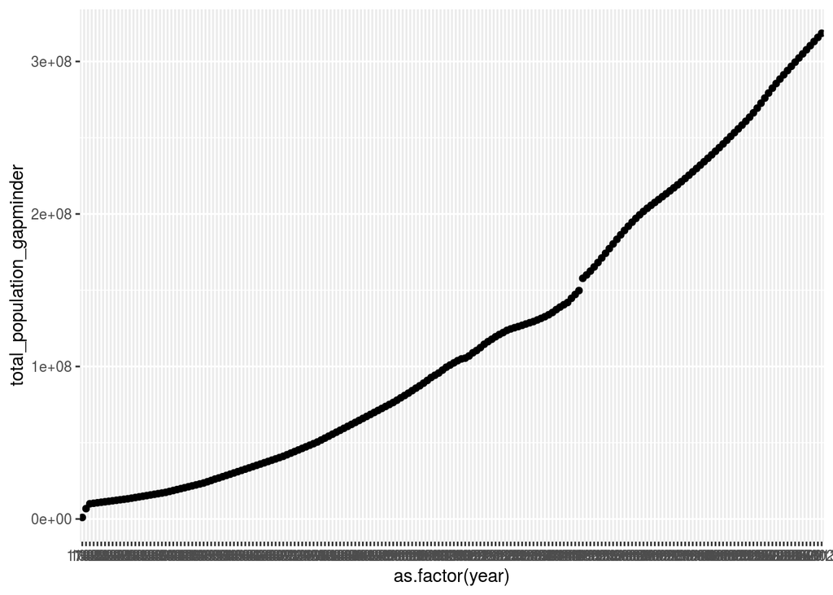

```r
coast_vs_waste %>%

 select(entity, year, code, total_population_gapminder) %>%
 filter(code=="USA") %>%

  ggplot(aes(x=as.factor(year), y=total_population_gapminder)) +
  geom_point(title = "For USA")
```

#FB: This looks like a good candidate fir a linear model!

```r
# left_join data
# then
# group_by _____
coast_vs_waste %>%
  select(entity, year, code, total_population_gapminder) %>%
 filter(code=="USA") %>%
lm(total_population_gapminder ~ year, data = .) %>%
  summary
```

```
##
## Call:
## lm(formula = total_population_gapminder ~ year, data = .)
##
## Residuals:
##       Min        1Q    Median        3Q       Max
## -26169483 -19764117  -5494298  13608202 205855098
##
## Coefficients:
##               Estimate Std. Error t value Pr(>|t|)
## (Intercept) -2.779e+09  5.983e+07  -46.44   <2e-16 ***
## year         1.514e+06  3.123e+04   48.48   <2e-16 ***
## ---
## Signif. codes:  0 '***' 0.001 '**' 0.01 '*' 0.05 '.' 0.1 ' ' 1
##
## Residual standard error: 25530000 on 194 degrees of freedom
## Multiple R-squared:  0.9237, Adjusted R-squared:  0.9233
## F-statistic:  2350 on 1 and 194 DF,  p-value: < 2.2e-16
```

```r
# write code to display them


# left_join data
# then
# group_by _____
coast_vs_waste %>%
 select(entity, year, code, total_population_gapminder) %>%
 filter(code=="USA") %>%
summary() #%>%
```

```
##     entity               year          code
##  Length:196         Min.   :1700   Length:196
##  Class :character   1st Qu.:1867   Class :character
##  Mode  :character   Median :1916   Mode  :character
##                     Mean   :1915
##                     3rd Qu.:1964
##                     Max.   :2013
##  total_population_gapminder
##  Min.   :  1000000
##  1st Qu.: 37498626
##  Median :101652500
##  Mean   :120373690
##  3rd Qu.:197684025
##  Max.   :318497630
```

```r
#model1 <- lm(total_population_gapminder ~ year, data = .) #%>% #conf.level_tidy(model1, conf.level = 0.95, func = stats::confint)
```

```r
# ggplot()
```

[output not shown]

```r
# Kick it off here!
```

Kick!